# CENSUS 2021

The ONS has published the demography and migration data of the [CENSUS 2021](https://census.gov.uk) including [population and household estimates](https://www.ons.gov.uk/peoplepopulationandcommunity/populationandmigration/populationestimates/bulletins/populationandhouseholdestimatesenglandandwales/census2021unroundeddata), [households and resident characteristics](https://www.ons.gov.uk/peoplepopulationandcommunity/householdcharacteristics/homeinternetandsocialmediausage/bulletins/householdandresidentcharacteristicsenglandandwales/census2021) and [international migration](https://www.ons.gov.uk/peoplepopulationandcommunity/populationandmigration/internationalmigration/bulletins/internationalmigrationenglandandwales/census2021).

A usual resident is anyone who on Census Day, 21 March 2021 was in the UK and had stayed or intended to stay in the UK for a period of 12 months or more, or had a permanent UK address and was outside the UK and intended to be outside the UK for less than 12 months.

A household is one person living alone or a group of people (not necessarily related) living at the same address who share cooking facilities and share a living room or sitting room or dining area.

## Population

The number of usual residents in Trafford according to the CENSUS 2021 is 235,052, representing an increment of 3.7% from the CENSUS 2011 when the number of usual residents was 226,578.

There are 120,644 females (51.33%) and 114,408 males (48.66%) in Trafford according to the CENSUS 2021. Similarly, there were 115,619 female (51.03%) and 110,959 male (48.97%) in 2011.

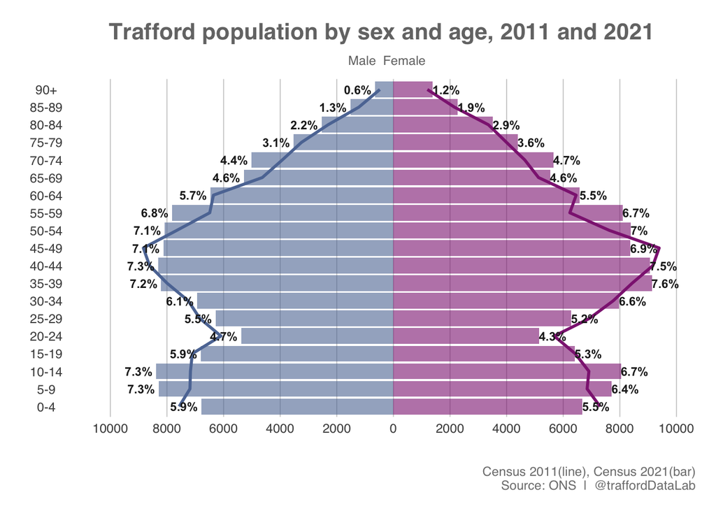

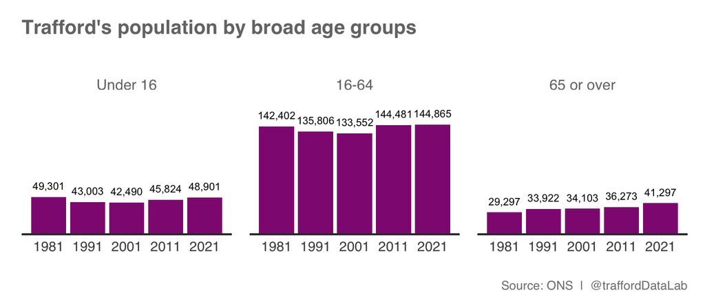

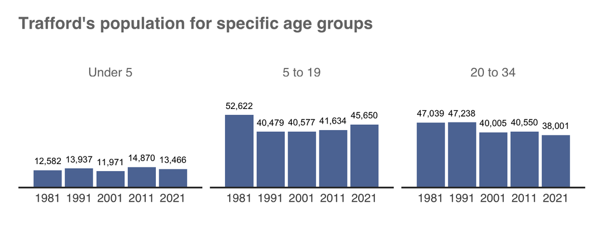

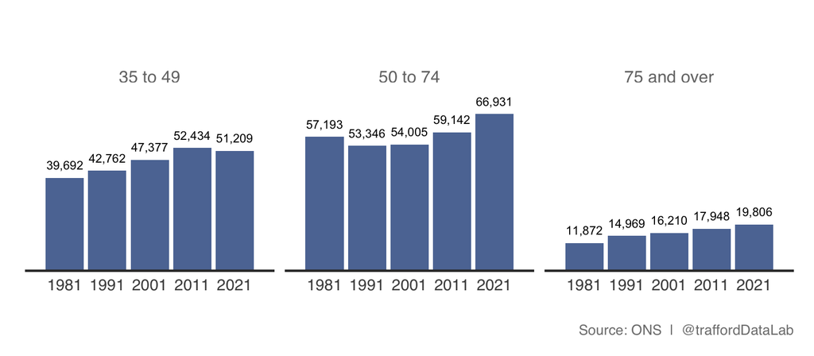

## Population Density

Trafford has the second lowest increase in population density in Greater Manchester compared to the 2011 census at 3.58%. Wigan’s increase was smallest at 3.55% while Salford had the highest at 15.24%. The average increase for all Greater Manchester is 6.61%

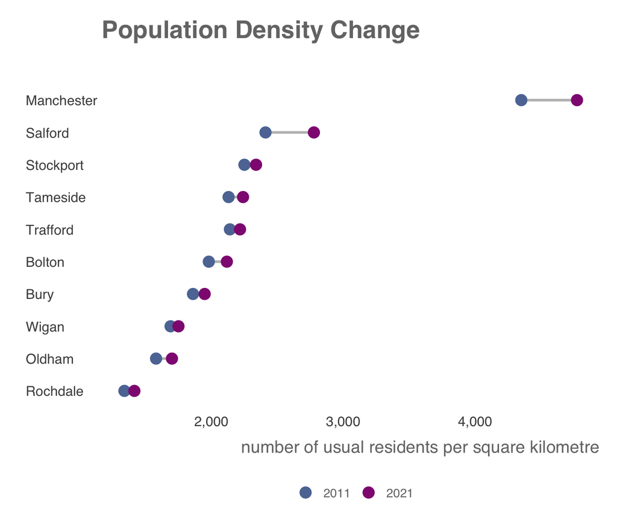

| LA | 2011 | 2021 | % Change |
| --- | --- | --- | --- |
| Manchester | 4,350 | 4,772.7 | 9.7 |
| Salford | 2,410 | 2,777.2 | 15.2 |
| Stockport | 2,250 | 2,338.3 | 3.9 |
| Tameside | 2,130 | 2,239.7 | 5.2 |
| Trafford | 2,140 | 2,216.7 | 3.6 |
| Bolton | 1,980 | 2,117.0 | 6.9 |
| Bury | 1,860 | 1,948.6 | 4.8 |
| Wigan | 1,690 | 1,750.0 | 3.6 |
| Oldham | 1,580 | 1,700.5 | 7.6 |
| Rochdale | 1,340 | 1,415.6 | 5.6 |

[interactive chart not shown]

## Households

Trafford has the lowest increase in households in Greater Manchester compared to the 2011 census at 1.89%. Salford had the largest increase at 11.16%. The average increase for all Greater Manchester is 4.37%

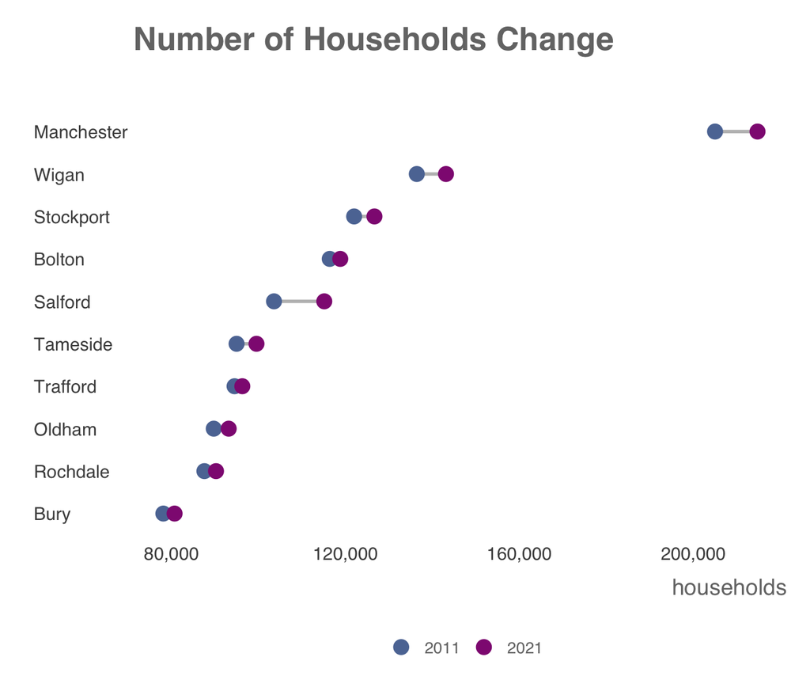

| LA | 2011 | 2021 | % Change |
| --- | --- | --- | --- |
| Manchester | 204,969 | 214,732 | 4.8 |
| Wigan | 136,386 | 143,105 | 4.9 |
| Stockport | 121,979 | 126,648 | 3.8 |
| Bolton | 116,371 | 118,790 | 2.1 |
| Salford | 103,556 | 115,116 | 11.2 |
| Tameside | 94,953 | 99,527 | 4.8 |
| Trafford | 94,484 | 96,269 | 1.9 |
| Oldham | 89,703 | 93,140 | 3.8 |
| Rochdale | 87,552 | 90,223 | 3.1 |
| Bury | 78,113 | 80,696 | 3.3 |

[interactive chart not shown]